# Homework 624 - Chapter 3

3.1

The UC Irvine Machine Learning Repository contains a data set related to glass identification. The data consit of 214 glass samples labeled as one of seven class categories. There are nine predicotrs, including the refrative index and percentages of eight elements: Na, Mg, Al, Si, K, Ca, Ba, and Fe.

```r
library(mlbench)
library(Hmisc)
data(Glass)
describe(Glass)
```

```
Glass

 10  Variables      214  Observations
-----------------------------------------------------------------------------------------------------------------------------------------
RI
       n  missing distinct     Info     Mean      Gmd      .05      .10      .25      .50      .75      .90      .95
     214        0      178        1    1.518 0.003054    1.515    1.516    1.517    1.518    1.519    1.522    1.524

lowest : 1.51115 1.51131 1.51215 1.51299 1.51316, highest: 1.52725 1.52739 1.52777 1.53125 1.53393
-----------------------------------------------------------------------------------------------------------------------------------------
Na
       n  missing distinct     Info     Mean      Gmd      .05      .10      .25      .50      .75      .90      .95
     214        0      142        1    13.41   0.8685    12.41    12.68    12.91    13.30    13.83    14.40    14.85

lowest : 10.73 11.02 11.03 11.23 11.45, highest: 14.99 15.01 15.15 15.79 17.38
-----------------------------------------------------------------------------------------------------------------------------------------
Mg
       n  missing distinct     Info     Mean      Gmd      .05      .10      .25      .50      .75      .90      .95
     214        0       94    0.992    2.685    1.417    0.000    0.000    2.115    3.480    3.600    3.757    3.850

lowest : 0.00 0.33 0.78 1.01 1.35, highest: 3.90 3.93 3.97 3.98 4.49
-----------------------------------------------------------------------------------------------------------------------------------------
Al
       n  missing distinct     Info     Mean      Gmd      .05      .10      .25      .50      .75      .90      .95
     214        0      118        1    1.445   0.5311    0.696    0.870    1.190    1.360    1.630    2.074    2.394

lowest : 0.29 0.34 0.47 0.51 0.56, highest: 2.79 2.88 3.02 3.04 3.50
-----------------------------------------------------------------------------------------------------------------------------------------
Si
       n  missing distinct     Info     Mean      Gmd      .05      .10      .25      .50      .75      .90      .95
     214        0      133        1    72.65   0.8047    71.31    71.77    72.28    72.79    73.09    73.30    73.52

lowest : 69.81 69.89 70.16 70.26 70.43, highest: 73.88 74.45 74.55 75.18 75.41
-----------------------------------------------------------------------------------------------------------------------------------------
K
       n  missing distinct     Info     Mean      Gmd      .05      .10      .25      .50      .75      .90      .95
     214        0       65    0.996   0.4971   0.4385   0.0000   0.0000   0.1225   0.5550   0.6100   0.6800   0.7600

lowest : 0.00 0.02 0.03 0.04 0.05, highest: 1.46 1.68 1.76 2.70 6.21
-----------------------------------------------------------------------------------------------------------------------------------------
```

[output cut: 11 more lines]

```
-----------------------------------------------------------------------------------------------------------------------------------------
Fe
       n  missing distinct     Info     Mean      Gmd      .05      .10      .25      .50      .75      .90      .95
     214        0       32    0.695  0.05701  0.08794    0.000    0.000    0.000    0.000    0.100    0.220    0.267

lowest : 0.00 0.01 0.03 0.05 0.06, highest: 0.32 0.34 0.35 0.37 0.51
-----------------------------------------------------------------------------------------------------------------------------------------
Type
       n  missing distinct
     214        0        6

Value          1     2     3     5     6     7
Frequency     70    76    17    13     9    29
Proportion 0.327 0.355 0.079 0.061 0.042 0.136
-----------------------------------------------------------------------------------------------------------------------------------------
```

1. Using visualizations, explore the predictor variables to understand their distributions as well as the relationships between predictors.

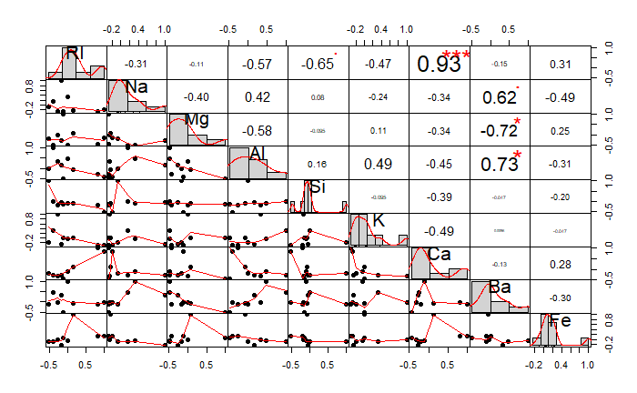

```r
library(corrplot)
library(PerformanceAnalytics)
Glass %>% select(-(Type)) %>% cor() %>% chart.Correlation(histogram=TRUE, pch=19)
```

2. Do there appear to be any outliers in the data? Are any predictors skewed?

```r
library(ggplot2)
ggplot(stack(Glass), aes(x = ind, y = values)) +
      facet_wrap(~ind, scales = "free", nrow = 1) +
      geom_boxplot()
```

[output not shown]

```
non-vector columns will be ignored
```

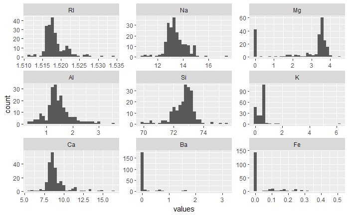

```r
library(ggplot2)
ggplot(stack(Glass), aes(values)) +
      facet_wrap(~ind, scales = "free") +
      geom_histogram()
```

> Visually, we can see that a couple of our variables are very skewed. The skewed variables are Mg, K, Ba, and Fe with many observations occuring at 0. Our other variables appear to have some slight skewness but not nearly as dramatic as the other variables.
3. Are there any relevant transformations of one or more predictors that might improve the classification model?

```r
apply(Glass %>% select(-(Type)), 2, BoxCoxTrans)
```

```
$RI
Box-Cox Transformation

214 data points used to estimate Lambda

Input data summary:
   Min. 1st Qu.  Median    Mean 3rd Qu.    Max.
  1.511   1.517   1.518   1.518   1.519   1.534

Largest/Smallest: 1.02
Sample Skewness: 1.6

Estimated Lambda: -2


$Na
Box-Cox Transformation

214 data points used to estimate Lambda

Input data summary:
   Min. 1st Qu.  Median    Mean 3rd Qu.    Max.
  10.73   12.91   13.30   13.41   13.82   17.38

Largest/Smallest: 1.62
Sample Skewness: 0.448

Estimated Lambda: -0.1
With fudge factor, Lambda = 0 will be used for transformations


$Mg
Box-Cox Transformation

214 data points used to estimate Lambda

Input data summary:
   Min. 1st Qu.  Median    Mean 3rd Qu.    Max.
  0.000   2.115   3.480   2.685   3.600   4.490

```

[output cut: 67 more lines]

```
  0.000   0.000   0.000   0.175   0.000   3.150

Lambda could not be estimated; no transformation is applied


$Fe
Box-Cox Transformation

214 data points used to estimate Lambda

Input data summary:
   Min. 1st Qu.  Median    Mean 3rd Qu.    Max.
0.00000 0.00000 0.00000 0.05701 0.10000 0.51000

Lambda could not be estimated; no transformation is applied
```

> From our results, it appears that few variables could benefit from transformations but we should be cautious to not create an overly complex model by applying all the transformations thoughtlessly. The variables that could benefit from transformation are RI, Na, Al, Si, and Ca.

3.2

The soybean data can also be found at UC Irvine Machine Learning Repository. Data was collected to predict diease in 683 Syobeas. The 35 predictors are mostly categorical and include information on the environmental conditions (e.g., temperature, precipitation) and plant conditions (e.g., left spots, mold growth). The outcome labels consist of 19 distinct classes. The data can be loaded via:

```r
library(mlbench)
data("Soybean")
```